# COM747 Week 11: Useful Maths and the R Toolkit

Lecture demonstrations and complete seminar solutions

> **How to use this notebook.** This week’s lectures were two guest talks (heart failure research and AI for ECGs) plus optional “useful mathematics” notes. Part A shows the rule-based vs machine learning idea on a simulated ECG. Part B turns each maths topic into R. Part C completes the seminar sheet “Topics and R packages to explore” (`exercise(7).pdf`), with a working version of every snippet. Lines that need the internet are guarded so the notebook still knits offline.

```r
library(jsonlite); library(xml2); library(data.table); library(parallel)
```

# Part A: Rule-based vs machine learning on an ECG

## A1. Simulate a heartbeat signal

A real ECG beat has a P wave, a sharp QRS complex and a T wave. We build one from Gaussian bumps (simulated, not patient data).

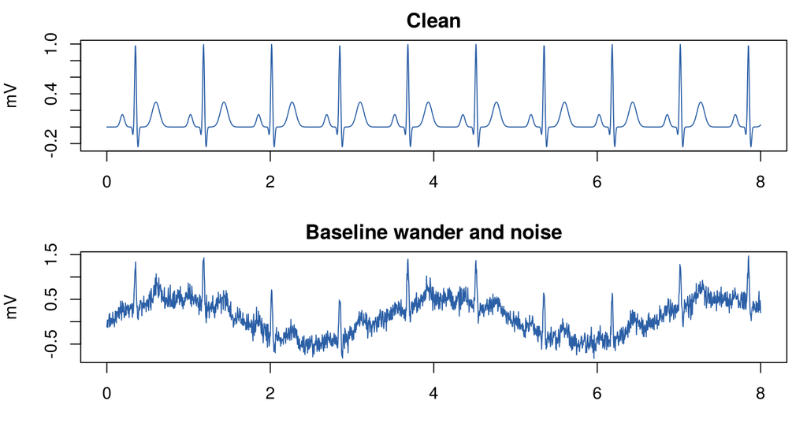

```r
fs <- 250                                    # samples per second
t  <- seq(0, 8, by = 1 / fs)                 # 8 seconds
beat_times <- seq(0.35, 7.9, by = 60 / 72)   # 72 beats per minute
bump <- function(t, mu, sd, a) a * exp(-0.5 * ((t - mu) / sd)^2)
ecg_clean <- rowSums(sapply(beat_times, function(b)
  bump(t, b - 0.16, 0.025, 0.15) +            # P wave
  bump(t, b - 0.03, 0.008, -0.10) +           # Q
  bump(t, b,        0.010, 1.00) +            # R peak
  bump(t, b + 0.03, 0.010, -0.25) +           # S
  bump(t, b + 0.25, 0.045, 0.30)))            # T wave
set.seed(3)
ecg_noisy <- ecg_clean + 0.5 * sin(2 * pi * 0.3 * t) + rnorm(length(t), 0, 0.12)   # baseline wander + noise
par(mfrow = c(2, 1), mar = c(3, 4, 2, 1))
plot(t, ecg_clean, type = "l", col = "#2b5fa6", ylab = "mV", main = "Clean")
plot(t, ecg_noisy, type = "l", col = "#2b5fa6", ylab = "mV", main = "Baseline wander and noise")
```

```r
par(mfrow = c(1, 1))
```

## A2. A rule: “a beat is an upward crossing of a threshold”

```r
detect_beats <- function(x, threshold, refractory = 0.2) {
  up <- which(head(x, -1) < threshold & tail(x, -1) >= threshold) + 1   # upward crossings
  keep <- c(); last <- -Inf
  for (i in up) if ((i - last) / fs > refractory) { keep <- c(keep, i); last <- i }  # ignore 200 ms after a beat
  t[keep]
}
score <- function(detected) {
  hit <- sapply(beat_times, function(b) any(abs(detected - b) < 0.1))
  c(true = length(beat_times), detected = length(detected), missed = sum(!hit),
    false_alarms = sum(sapply(detected, function(d) all(abs(d - beat_times) >= 0.1))))
}
score(detect_beats(ecg_clean, 0.6))   # perfect on a clean signal
```

```
##         true     detected       missed false_alarms
##           10           10            0            0
```

```r
score(detect_beats(ecg_noisy, 0.6))   # the same rule breaks
```

```
##         true     detected       missed false_alarms
##           10           20            2           12
```

## A3. The rule-based fix: preprocess first

This is what classic ECG software does: remove the baseline, smooth, then detect.

```r
baseline <- stats::filter(ecg_noisy, rep(1 / 151, 151), sides = 2)    # 0.6 s moving average = slow wander
baseline[is.na(baseline)] <- mean(ecg_noisy)
smoothed <- stats::filter(ecg_noisy - baseline, rep(1 / 5, 5), sides = 2)
smoothed[is.na(smoothed)] <- 0
score(detect_beats(as.numeric(smoothed), 0.5))
```

```
##         true     detected       missed false_alarms
##           10           10            0            0
```

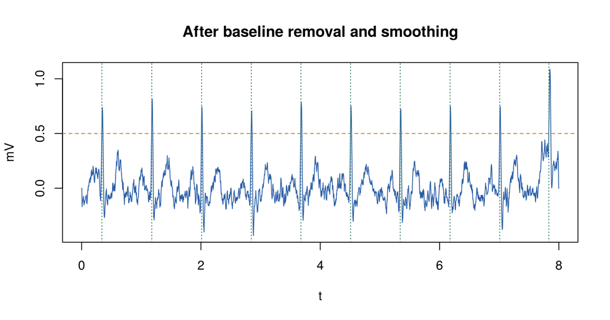

```r
plot(t, smoothed, type = "l", col = "#2b5fa6", ylab = "mV", main = "After baseline removal and smoothing")
abline(h = 0.5, col = "#d0791a", lty = 2)
abline(v = detect_beats(as.numeric(smoothed), 0.5), col = "#2f7d5b", lty = 3)
```

**Ask:** We had to *know* about baseline wander to fix it. A machine learning model trained on thousands of labelled noisy ECGs learns to ignore wander without being told, but then it can’t tell us *why* it decided. That is the trade-off in the PulseAI talk.

# Part B: Useful mathematics in R

## B1. Number systems and scientific notation

```r
x <- 5L; is.integer(x)               # integer (Z)
```

```
## [1] TRUE
```

```r
1 / 3                                # a rational, stored as a double
```

```
## [1] 0.3333333
```

```r
sqrt(2); pi; exp(1)                  # irrationals (R)
```

```
## [1] 1.414214
```

```
## [1] 3.141593
```

```
## [1] 2.718282
```

```r
sqrt(as.complex(-1))                 # complex (C): 0+1i
```

```
## [1] 0+1i
```

```r
0.1 + 0.2 == 0.3                     # FALSE: doubles are approximations
```

```
## [1] FALSE
```

```r
isTRUE(all.equal(0.1 + 0.2, 0.3))    # TRUE: compare with a tolerance
```

```
## [1] TRUE
```

```r
for (v in c(0.000123, 0.0000123, 123456, 1e5, 2^100)) print(v)   # R picks fixed or scientific, whichever is shorter
```

```
## [1] 0.000123
## [1] 1.23e-05
## [1] 123456
## [1] 1e+05
## [1] 1.267651e+30
```

```r
c(0.000123, 123456)                  # a vector shares one format, so this prints all in scientific
```

```
## [1] 1.23000e-04 1.23456e+05
```

```r
format(0.0000123, scientific = FALSE)
```

```
## [1] "0.0000123"
```

```r
options(scipen = 10); 0.0000123; options(scipen = 0)   # discourage scientific notation globally
```

```
## [1] 0.0000123
```

Operations: addition and multiplication are commutative and associative; multiplication distributes over addition.

```r
c(2 + 4 == 4 + 2, (2 + 3) + 4 == 2 + (3 + 4), 2 * (3 + 4) == 2 * 3 + 2 * 4)
```

```
## [1] TRUE TRUE TRUE
```

## B2. Sets and logic

```r
A <- 1:5; B <- 4:7
union(A, B)
```

```
## [1] 1 2 3 4 5 6 7
```

```r
intersect(A, B)
```

```
## [1] 4 5
```

```r
setdiff(A, B); setdiff(B, A)
```

```
## [1] 1 2 3
```

```
## [1] 6 7
```

```r
union(setdiff(A, B), setdiff(B, A))          # symmetric difference
```

```
## [1] 1 2 3 6 7
```

```r
3 %in% A; 9 %in% A
```

```
## [1] TRUE
```

```
## [1] FALSE
```

```r
length(union(A, B)) == length(A) + length(B) - length(intersect(A, B))   # inclusion-exclusion
```

```
## [1] TRUE
```

```r
S <- 1:4
S[S > 2]                                      # the predicate P(x) = "x > 2" selects elements
```

```
## [1] 3 4
```

```r
sapply(S, function(x) x > 2)                  # the truth function T_P : S -> {TRUE, FALSE}
```

```
## [1] FALSE FALSE  TRUE  TRUE
```

```r
tt <- expand.grid(P = c(TRUE, FALSE), Q = c(TRUE, FALSE))
tt$AND <- tt$P & tt$Q
tt$OR  <- tt$P | tt$Q
tt$XOR <- xor(tt$P, tt$Q)
tt$IMPLIES <- !tt$P | tt$Q
tt$NOT_AND <- !(tt$P & tt$Q)
tt$NOTP_OR_NOTQ <- !tt$P | !tt$Q
tt
```

```
##       P     Q   AND    OR   XOR IMPLIES NOT_AND NOTP_OR_NOTQ
## 1  TRUE  TRUE  TRUE  TRUE FALSE    TRUE   FALSE        FALSE
## 2 FALSE  TRUE FALSE  TRUE  TRUE    TRUE    TRUE         TRUE
## 3  TRUE FALSE FALSE  TRUE  TRUE   FALSE    TRUE         TRUE
## 4 FALSE FALSE FALSE FALSE FALSE    TRUE    TRUE         TRUE
```

```r
identical(tt$NOT_AND, tt$NOTP_OR_NOTQ)        # De Morgan's law
```

```
## [1] TRUE
```

## B3. Functions

```r
A <- -2:3; B <- 0:9
f <- function(x) x^2
f(A)                       # each input gets exactly one output
```

```
## [1] 4 1 0 1 4 9
```

```r
sort(unique(f(A)))         # the range: 0 1 4 9
```

```
## [1] 0 1 4 9
```

```r
all(f(A) %in% B)           # every output is in the codomain
```

```
## [1] TRUE
```

```r
any(duplicated(f(A)))      # TRUE: not one-to-one (f(-2) = f(2))
```

```
## [1] TRUE
```

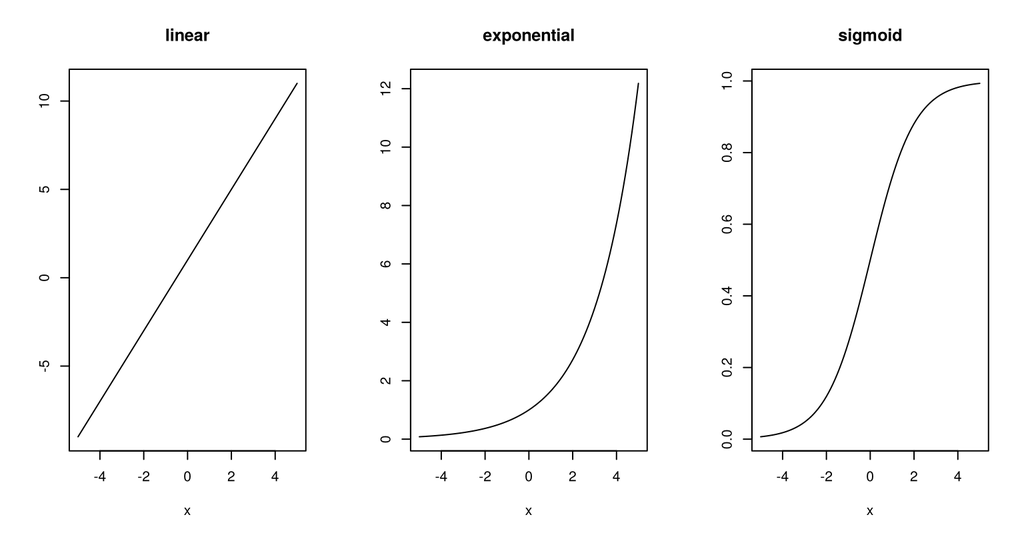

```r
par(mfrow = c(1, 3))
curve(2 * x + 1, -5, 5, main = "linear", ylab = "")
curve(exp(0.5 * x), -5, 5, main = "exponential", ylab = "")
curve(1 / (1 + exp(-x)), -5, 5, main = "sigmoid", ylab = "")
```

```r
par(mfrow = c(1, 1))
```

## B4. Matrices

```r
A <- matrix(1:6, nrow = 2, byrow = TRUE)
B <- matrix(7:12, nrow = 3, byrow = TRUE)
A; B
```

```
##      [,1] [,2] [,3]
## [1,]    1    2    3
## [2,]    4    5    6
```

```
##      [,1] [,2]
## [1,]    7    8
## [2,]    9   10
## [3,]   11   12
```

```r
dim(A %*% B)               # (2 x 3)(3 x 2) = 2 x 2
```

```
## [1] 2 2
```

```r
A %*% B
```

```
##      [,1] [,2]
## [1,]   58   64
## [2,]  139  154
```

```r
sum(A[1, ] * B[, 1])       # element [1, 1] by hand: 1*7 + 2*9 + 3*11 = 58
```

```
## [1] 58
```

```r
t(A)                       # transpose
```

```
##      [,1] [,2]
## [1,]    1    4
## [2,]    2    5
## [3,]    3    6
```

```r
try(A %*% A)               # non-conformable: 2 x 3 times 2 x 3
```

```
## Error in A %*% A : non-conformable arguments
```

```r
A * A                      # element-wise, not matrix multiplication
```

```
##      [,1] [,2] [,3]
## [1,]    1    4    9
## [2,]   16   25   36
```

```r
# A distance table is symmetric
d <- matrix(c(0, 785, 3169, 5657, 785, 0, 3593, 6706, 3169, 3593, 0, 4102, 5657, 6706, 4102, 0), 4,
            dimnames = list(c("London", "Madrid", "New York", "Tokyo"), c("London", "Madrid", "New York", "Tokyo")))
d
```

```
##          London Madrid New York Tokyo
## London        0    785     3169  5657
## Madrid      785      0     3593  6706
## New York   3169   3593        0  4102
## Tokyo      5657   6706     4102     0
```

```r
isSymmetric(d)
```

```
## [1] TRUE
```

Matrices everywhere in ML: a regression prediction is `X %*% beta`.

```r
fit <- lm(mpg ~ wt + hp, data = mtcars)
X <- model.matrix(fit)                 # a column of 1s, then wt and hp
head(X %*% coef(fit))                  # same as fitted(fit)
```

```
##                       [,1]
## Mazda RX4         23.57233
## Mazda RX4 Wag     22.58348
## Datsun 710        25.27582
## Hornet 4 Drive    21.26502
## Hornet Sportabout 18.32727
## Valiant           20.47382
```

```r
all.equal(as.numeric(X %*% coef(fit)), as.numeric(fitted(fit)))
```

```
## [1] TRUE
```

```r
solve(t(X) %*% X) %*% t(X) %*% mtcars$mpg    # the least-squares formula gives lm()'s coefficients
```

```
##                    [,1]
## (Intercept) 37.22727012
## wt          -3.87783074
## hp          -0.03177295
```

## B5. Graphs and adjacency matrices

```r
M <- matrix(c(0, 1, 1, 2, 0,
              1, 0, 0, 0, 0,
              0, 0, 1, 1, 0,
              0, 0, 0, 0, 1,
              0, 0, 1, 0, 1), nrow = 5, byrow = TRUE,
            dimnames = list(LETTERS[1:5], LETTERS[1:5]))
M
```

```
##   A B C D E
## A 0 1 1 2 0
## B 1 0 0 0 0
## C 0 0 1 1 0
## D 0 0 0 0 1
## E 0 0 1 0 1
```

```r
rowSums(M)        # out-degree
```

```
## A B C D E
## 4 1 2 1 2
```

```r
colSums(M)        # in-degree: C has 3 (from A, itself and E)
```

```
## A B C D E
## 1 1 3 3 2
```

```r
M %*% M           # number of paths of length 2 between each pair
```

```
##   A B C D E
## A 1 0 1 1 2
## B 0 1 1 2 0
## C 0 0 1 1 1
## D 0 0 1 0 1
## E 0 0 2 1 1
```

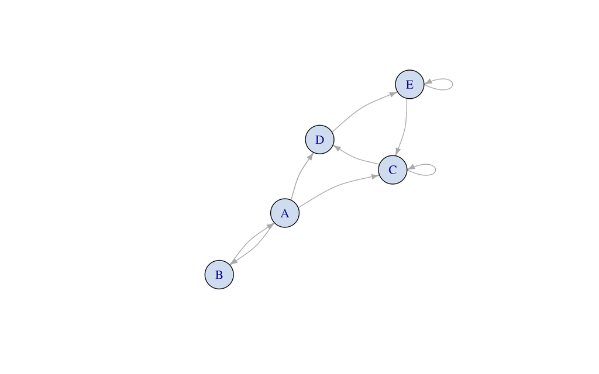

```r
library(igraph)
g <- graph_from_adjacency_matrix(M, mode = "directed")
set.seed(2)
plot(g, vertex.color = "#cfdcf0", vertex.size = 30, edge.arrow.size = 0.5, edge.curved = 0.2)
```

```r
degree(g, mode = "in"); degree(g, mode = "out")
```

```
## A B C D E
## 1 1 3 3 2
```

```
## A B C D E
## 4 1 2 1 2
```

## B6. Statistics and variable types

```r
df <- data.frame(
  blood  = factor(c("A", "O", "B", "O", "AB")),                                   # nominal
  income = factor(c("<20k", "20-40k", ">40k", "<20k", "20-40k"),
                  levels = c("<20k", "20-40k", ">40k"), ordered = TRUE),           # ordinal
  height = c(172.1, 165.4, 180.2, 158.9, 175.0))                                  # metric (continuous)
str(df)
```

```
## 'data.frame':    5 obs. of  3 variables:
##  $ blood : Factor w/ 4 levels "A","AB","B","O": 1 4 3 4 2
##  $ income: Ord.factor w/ 3 levels "<20k"<"20-40k"<..: 1 2 3 1 2
##  $ height: num  172 165 180 159 175
```

```r
table(df$blood)              # nominal: counts and the mode
```

```
##
##  A AB  B  O
##  1  1  1  2
```

```r
max(df$income); median(as.integer(df$income))   # ordinal: order makes sense
```

```
## [1] >40k
## Levels: <20k < 20-40k < >40k
```

```
## [1] 2
```

```r
mean(df$height); sd(df$height)                  # metric: means and SDs make sense
```

```
## [1] 170.32
```

```
## [1] 8.326284
```

# Part C: The seminar sheet, worked

## C1. Reading HTML: rvest

```r
library(rvest)
# The sheet's code needs the internet. tryCatch keeps the notebook running offline.
title <- tryCatch({
  webpage <- read_html("https://www.ulster.ac.uk")
  html_node(webpage, "title") %>% html_text()
}, error = function(e) paste("No connection:", conditionMessage(e)))
title
```

```
## [1] "No connection: CONNECT tunnel failed, response 403"
```

```r
# The same idea on a page we write ourselves, so you can see how selectors work
page <- read_html('<html><head><title>COM747</title></head><body>
  <h1>Modules</h1><ul><li class="mod">Data Science</li><li class="mod">Machine Learning</li></ul>
  <table><tr><th>Week</th><th>Topic</th></tr><tr><td>8</td><td>Clustering</td></tr><tr><td>9</td><td>Rules</td></tr></table>
  </body></html>')
html_node(page, "title") %>% html_text()
```

```
## [1] "COM747"
```

```r
html_nodes(page, "li.mod") %>% html_text()      # CSS selector: <li> with class "mod"
```

```
## [1] "Data Science"     "Machine Learning"
```

```r
html_table(html_node(page, "table"))            # tables come back as data frames
```

```
## # A tibble: 2 x 2
##    Week Topic
##   <int> <chr>
## 1     8 Clustering
## 2     9 Rules
```

## C2. XML: xml2

```r
doc <- read_xml("<cars><car name='Mazda RX4' mpg='21'/><car name='Datsun 710' mpg='22.8'/></cars>")
cars <- xml_find_all(doc, "//car")
data.frame(name = xml_attr(cars, "name"), mpg = as.numeric(xml_attr(cars, "mpg")))
```

```
##         name  mpg
## 1  Mazda RX4 21.0
## 2 Datsun 710 22.8
```

## C3. JSON: jsonlite

```r
mtcars <- datasets::mtcars
mtcarsJSONData <- toJSON(mtcars, pretty = TRUE)
cat(substr(mtcarsJSONData, 1, 400))           # first record or two; cat() prints the whole thing
```

```
## [
##   {
##     "mpg": 21,
##     "cyl": 6,
##     "disp": 160,
##     "hp": 110,
##     "drat": 3.9,
##     "wt": 2.62,
##     "qsec": 16.46,
##     "vs": 0,
##     "am": 1,
##     "gear": 4,
##     "carb": 4,
##     "_row": "Mazda RX4"
##   },
##   {
##     "mpg": 21,
##     "cyl": 6,
##     "disp": 160,
##     "hp": 110,
##     "drat": 3.9,
##     "wt": 2.875,
##     "qsec": 17.02,
##     "vs": 0,
##     "am": 1,
##     "gear": 4,
##     "carb": 4,
##     "_row": "Mazda RX4
```

```r
myCarDataset <- fromJSON(mtcarsJSONData)
head(myCarDataset)                             # View() opens a window; head() works when knitting
```

```
##                    mpg cyl disp  hp drat    wt  qsec vs am gear carb
## Mazda RX4         21.0   6  160 110 3.90 2.620 16.46  0  1    4    4
## Mazda RX4 Wag     21.0   6  160 110 3.90 2.875 17.02  0  1    4    4
## Datsun 710        22.8   4  108  93 3.85 2.320 18.61  1  1    4    1
## Hornet 4 Drive    21.4   6  258 110 3.08 3.215 19.44  1  0    3    1
## Hornet Sportabout 18.7   8  360 175 3.15 3.440 17.02  0  0    3    2
## Valiant           18.1   6  225 105 2.76 3.460 20.22  1  0    3    1
```

```r
all.equal(mtcars, myCarDataset)                # identical, car names included (the "_row" field)
```

```
## [1] TRUE
```

```r
toJSON(head(mtcars, 2), dataframe = "columns") # the compact column form
```

```
## {"mpg":[21,21],"cyl":[6,6],"disp":[160,160],"hp":[110,110],"drat":[3.9,3.9],"wt":[2.62,2.875],"qsec":[16.46,17.02],"vs":[0,0],"am":[1,1],"gear":[4,4],"carb":[4,4],"_row":["Mazda RX4","Mazda RX4 Wag"]}
```

`toJSON()` keeps 4 decimal places by default. For data with more precision use `toJSON(x, digits = NA)`.

## C4. Network analysis

`statnet` is a large suite (install time is long); `igraph` (used in B5) covers most needs.

```r
set.seed(1)
friends <- sample_gnp(20, 0.15)                     # a random "social network" of 20 people
c(people = vcount(friends), friendships = ecount(friends))
```

```
##      people friendships
##          20          28
```

```r
head(sort(degree(friends), decreasing = TRUE))     # the most connected people
```

```
## [1] 5 5 4 4 4 4
```

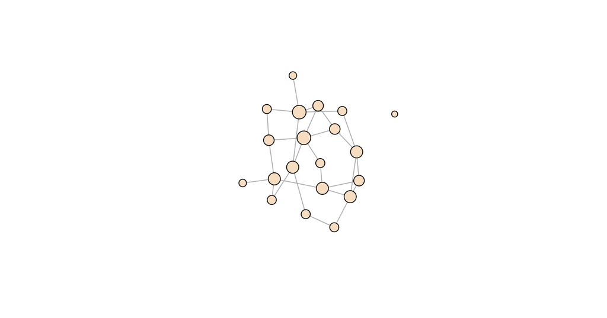

```r
plot(friends, vertex.size = 8 + 2 * degree(friends), vertex.label = NA, vertex.color = "#f6dcc0")
```

## C5. data.table and fread()

```r
n <- 1e6
big <- data.frame(id = 1:n, x = rnorm(n), group = sample(letters, n, replace = TRUE))
f <- tempfile(fileext = ".csv")
fwrite(big, f)                                   # data.table's fast writer
t_base <- system.time(a <- read.csv(f))
t_fread <- system.time(b <- fread(f))
rbind(read.csv = t_base[1:3], fread = t_fread[1:3])
```

```
##          user.self sys.self elapsed
## read.csv     2.703      0.1   2.807
## fread        0.072      0.0   0.071
```

```r
class(b)                                          # a data.table is also a data.frame
```

```
## [1] "data.table" "data.frame"
```

```r
b[, .(mean_x = mean(x), n = .N), by = group][order(group)][1:5]   # fast grouped summary
```

```
##    group       mean_x     n
## 1:     a  0.005277552 38452
## 2:     b -0.004213347 38716
## 3:     c -0.005968661 38210
## 4:     d  0.004035361 38435
## 5:     e -0.004960461 38827
```

## C6. Timing code: system.time()

```r
system.time(rnorm(1000000))
```

```
##    user  system elapsed
##   0.029   0.000   0.028
```

```r
# Compare a loop with the vectorised version
loop_sq <- function(v) { out <- numeric(length(v)); for (i in seq_along(v)) out[i] <- v[i]^2; out }
v <- runif(2e6)
rbind(loop = system.time(loop_sq(v))[1:3], vectorised = system.time(v^2)[1:3])
```

```
##            user.self sys.self elapsed
## loop           0.093        0   0.093
## vectorised     0.003        0   0.003
```

```r
# Training time of two algorithms
library(rpart); library(e1071)
rbind(tree = system.time(rpart(Species ~ ., iris))[1:3], svm = system.time(svm(Species ~ ., iris))[1:3])
```

```
##      user.self sys.self elapsed
## tree     0.005        0   0.005
## svm      0.004        0   0.004
```

## C7. Multiple cores: parallel

The sheet says `install.packages("parallel")`. Don’t: `parallel` is part of base R and the install gives a warning. Just `library(parallel)`.

```r
detectCores()
```

```
## [1] 2
```

```r
boot_fit <- function(i) coef(lm(mpg ~ wt + hp, data = mtcars[sample(32, replace = TRUE), ]))
set.seed(1)
t1 <- system.time(r1 <- lapply(1:400, boot_fit))
cores <- max(1, min(4, detectCores()))
t2 <- system.time(r2 <- mclapply(1:400, boot_fit, mc.cores = cores))   # forks: Mac/Linux
rbind(sequential = t1[1:3], parallel = t2[1:3])
```

```
##            user.self sys.self elapsed
## sequential     0.266    0.000   0.267
## parallel       0.004    0.012   0.228
```

```r
# On Windows use a cluster instead:
# cl <- makeCluster(cores); clusterExport(cl, "mtcars"); parLapply(cl, 1:400, boot_fit); stopCluster(cl)
boot <- do.call(rbind, r1)
apply(boot, 2, quantile, c(0.025, 0.975))      # bootstrap 95% intervals for the coefficients
```

```
##       (Intercept)        wt          hp
## 2.5%     33.08085 -5.422540 -0.05045079
## 97.5%    42.09855 -2.542903 -0.02080325
```

The parallel speed-up is small here because each task is tiny and starting workers has a cost; it pays off for long tasks such as cross-validating many models. `doParallel` lets `caret::train()` and `foreach` use the cores automatically.

## C8. Shiny

A complete app is only a few lines. It runs in a browser, so it can’t run inside a knitted file; copy it into the console.

```r
library(shiny)
runExample("01_hello")          # the sheet's demo

ui <- fluidPage(
  titlePanel("k-means on iris"),
  sliderInput("k", "Number of clusters", min = 1, max = 6, value = 3),
  plotOutput("plot"))
server <- function(input, output) {
  output$plot <- renderPlot({
    km <- kmeans(scale(iris[, 1:4]), centers = input$k, nstart = 25)
    plot(iris$Petal.Length, iris$Petal.Width, col = km$cluster, pch = 19,
         xlab = "Petal length", ylab = "Petal width")
  })
}
shinyApp(ui, server)
```

## C9. Apache Spark (sparklyr)

```r
# Needs Java and a local Spark install: spark_install()
library(sparklyr)
sc <- spark_connect(master = "local")
cars_tbl <- copy_to(sc, mtcars)
library(dplyr)
cars_tbl %>% group_by(cyl) %>% summarise(mpg = mean(mpg))   # runs inside Spark
spark_disconnect(sc)
```

# Summary

| Topic | R |
| --- | --- |
| Sets | `union()`, `intersect()`, `setdiff()`, `%in%`, `setequal()` |
| Logic | `&`, `\|`, `!`, `xor()`, `expand.grid()` for truth tables |
| Functions | `function(x) ...`, `curve()` |
| Matrices | `matrix()`, `%*%`, `t()`, `solve()`, `isSymmetric()` |
| Graphs | adjacency matrix, `rowSums()` / `colSums()`, `igraph::graph_from_adjacency_matrix()` |
| Variable types | `factor()`, `factor(..., ordered = TRUE)`, numeric |
| Web and data formats | `rvest::read_html()`, `html_nodes()`, `xml2::read_xml()`, `jsonlite::toJSON()` / `fromJSON()` |
| Speed | `data.table::fread()`, `system.time()`, `parallel::mclapply()`, `detectCores()` |
| Apps | `shiny::fluidPage()`, `shinyApp()` |